# YearUp Labor Project: Replicating Code

### Race (Black) - Difference in actual vs counterfactual change in earnings

Finally, to get the difference in actual vs counterfactual earnings, we take a simple difference. This was accomplished in code by reshaping the yu_treatment_control dataframe from long to wide, using the “treatment” variable as the key. Then, the actual column was subtracted by the counterfactual column to produce the change column, which is the outcome variable in the decomposition analysis.

```r
outcome<- "log_d_earn_change"
lm1<- as.formula(
  paste(outcome,
        paste(c(black), collapse = " + "),
        sep = " ~ "))
model1<-lm(lm1, data = yu_df_diff)

lm2<- as.formula(
  paste(outcome,
        paste(c(black,background1), collapse = " + "),
        sep = " ~ "))
model2<-lm(lm2, data = yu_df_diff)

lm3<- as.formula(
  paste(outcome,
        paste(c(black,background1,occexp), collapse = " + "),
        sep = " ~ "))
model3<-lm(lm3, data = yu_df_diff)

lm4<- as.formula(
  paste(outcome,
        paste(c(black,background1,occexp,region), collapse = " + "),
       sep = " ~ "))
model4<-lm(lm4,  data = yu_df_diff)

lm5<- as.formula(
  paste(outcome,
        paste(c(black,background1,occexp,region, "log_real_yearly_earnings_1"), collapse = " + "),
       sep = " ~ "))
model5<-lm(lm5,  data = yu_df_diff)
```

```r
stargazer(model1, model2,model3, model4,model5,
          title="OLS regression of counterfactual difference in log earnings between t and t+1 for program particpants, consecutively adding more covariates",
          type = 'html',
          omit=c(background1,occexp,region,"log_real_yearly_earnings_1"),
          df = FALSE,
          add.lines = list(c("Demographics", "No", "Yes", "Yes", "Yes","Yes"),c("Occupation+Experience", "No", "No","Yes","Yes", "Yes"),  c("Local labor market characteristics", "No", "No", "No", "Yes","Yes" ), c("Earnings at t", "No", "No", "No", "No","Yes")),
          notes.append = FALSE,
          notes = c("Dependent variable: predicted change in log earnings.","Significance level: * p$<$0.10, ** p$<$0.05, *** p$<$0.01. For further notes, see text." )
)
```

**OLS regression of counterfactual difference in log earnings between t and t+1 for program particpants, consecutively adding more covariates**

|  | *Dependent variable:* |  |  |  |  |
| --- | --- | --- | --- | --- | --- |
|  | log_d_earn_change |  |  |  |  |
|  | (1) | (2) | (3) | (4) | (5) |
| black | -0.060*** | -0.044** | -0.053*** | -0.025 | -0.033* |
|  | (0.018) | (0.019) | (0.018) | (0.019) | (0.019) |
| Constant | 0.501*** | 0.162 | 0.253** | 1.050 | 1.022 |
|  | (0.012) | (0.126) | (0.127) | (0.824) | (0.799) |
| Demographics | No | Yes | Yes | Yes | Yes |
| Occupation+Experience | No | No | Yes | Yes | Yes |
| Local labor market characteristics | No | No | No | Yes | Yes |
| Earnings at t | No | No | No | No | Yes |
| Observations | 1,132 | 1,132 | 1,132 | 1,132 | 1,132 |
| R<sup>2</sup> | 0.010 | 0.084 | 0.113 | 0.166 | 0.217 |
| Adjusted R<sup>2</sup> | 0.009 | 0.079 | 0.106 | 0.150 | 0.200 |
| Residual Std. Error | 0.299 | 0.288 | 0.284 | 0.277 | 0.268 |
| F Statistic | 11.108*** | 17.215*** | 15.862*** | 10.062*** | 13.324*** |
| *Note:* | Dependent variable: predicted change in log earnings. |  |  |  |  |
|  | Significance level: * p<0.10, ** p<0.05, *** p<0.01. For further notes, see text. |  |  |  |  |

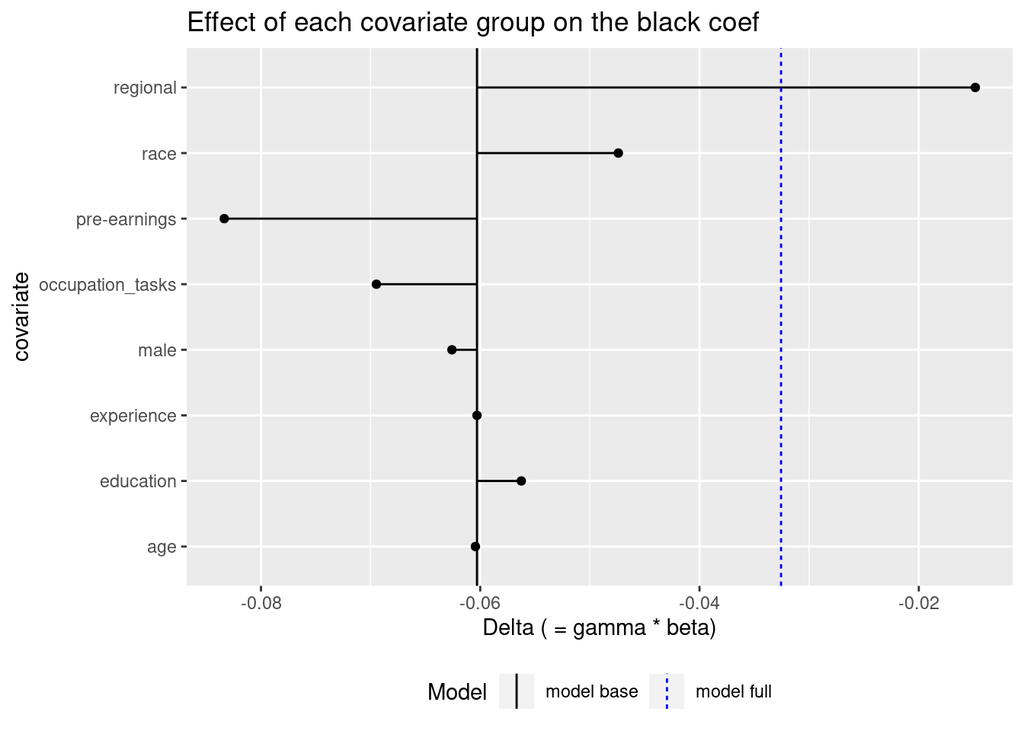

```r
dec_long_2 <- dec_covar(object = model5, var_main = c("black"), format = "long", add_coefs = TRUE, conf.int = TRUE)

# add occupation group
 dec_long_2a<-dec_long_2 %>%
   mutate(group= if_else(covariate %in% c("male"), "male",
            if_else(covariate %in% c("age", "age2"), "age",
                         if_else(covariate %in% c("race_white","race_asian"), "race",
                                if_else(covariate %in% c("experience", "experience2"), "experience",
                                        if_else(covariate %in% c("log_real_yearly_earnings_1"), "pre-earnings",
   if_else(covariate %in% occupation, "occupation_group",
           if_else(covariate %in% tasks, "occupation_tasks",
           if_else(covariate %in% region, "regional",
                         "education")))))))))
#
#
sumthose<-  c("beta_K", "beta_K_low", "beta_K_high",
              "gamma","gamma_low", "gamma_high", "delta")

keepthose<- c("beta_var_base", "beta_var_full")

dec_long_2b <- dec_long_2a %>%
  group_by(group)%>%
  summarise_at(vars(all_of(sumthose)), funs(sum), na.rm=TRUE)%>%
  rename(covariate=group)

dec_long_2c <- dec_long_2a %>%
  group_by(group)%>%
  summarise_at(vars(all_of(keepthose)), funs(max), na.rm=TRUE)%>%
  rename(covariate=group)

dec_long_2d <-left_join(dec_long_2b,dec_long_2c,by="covariate")

dec_long_2d$variable<-c(rep("black", times=(dim(dec_long_2d)[1])))

plot_dec(dec_long_2d) +
   ggtitle("Effect of each covariate group on the black coef")
```

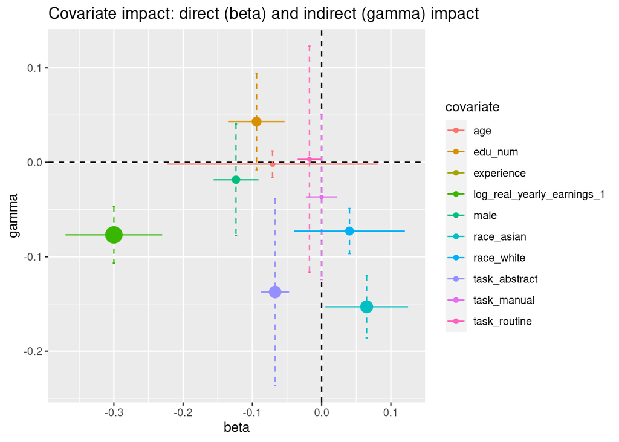

```r
dec_long_2<-dec_long_2 %>%
  filter(!(covariate %in% c(region, colnames(occ_group1))))

plot_gamma_beta(dec_long_2, add_CI = TRUE) +
  ggtitle("Covariate impact: direct (beta) and indirect (gamma) impact")
```

## Age Decomposition

### Age - Actual changes in wage

```r
outcome<- "log_d_earn"#"log_d_earn"#""

age<- c("age")#,#"log_real_yearly_earnings_1")

# cps <- dummy_cols(cps, select_columns = 'occ1digit')
occ_group1 <-yu_df %>%
  select(tidyselect::vars_select(colnames(cps_vars), starts_with('occ1digit_', ignore.case = TRUE)))
occupation<-colnames(occ_group1)
occupation<-occupation[occupation!="occ1digit_transport"]

tasks<-c("task_abstract","task_routine","task_manual" )
background1<-c("black","race_white","race_asian","edu_num","male")

occexp<- c("experience",tasks)#,occupation)


region<-c("cty_pop2000","cz_pop2000","intersects_msa",
                    "cs00_seg_inc","cs00_seg_inc_pov25","cs00_seg_inc_aff75",
                    "cs_race_theil_2000","gini99","poor_share","inc_share_1perc",
                    "frac_middleclass","rel_tot","cs_frac_black",
                    "cs_frac_hisp","unemp_rate","pop_d_2000_1980","lf_d_2000_1980",
                    "cs_labforce","cs_elf_ind_man","cs_born_foreign","mig_inflow",
                    "mig_outflow","pop_density","frac_traveltime_lt15","hhinc00",
                    "median_house_value","cs_educ_ba",
                    "cs_fam_wkidsinglemom","crime_total","subcty_exp_pc",
                    "taxrate","tax_st_diff_top20")
```

```r
outcome<- "log_d_earn"
lm1<- as.formula(
  paste(outcome,
        paste(c(age), collapse = " + "),
        sep = " ~ "))
model1<-lm(lm1, data = yu_df)

lm2<- as.formula(
  paste(outcome,
        paste(c(age,background1), collapse = " + "),
        sep = " ~ "))
model2<-lm(lm2, data = yu_df)

lm3<- as.formula(
  paste(outcome,
        paste(c(age,background1,occexp), collapse = " + "),
        sep = " ~ "))
model3<-lm(lm3, data = yu_df)

lm4<- as.formula(
  paste(outcome,
        paste(c(age,background1,occexp,region), collapse = " + "),
       sep = " ~ "))
model4<-lm(lm4,  data = yu_df)

lm5<- as.formula(
  paste(outcome,
        paste(c(age,background1,occexp,region, "log_real_yearly_earnings_1"), collapse = " + "),
       sep = " ~ "))
model5<-lm(lm5,  data = yu_df)
```

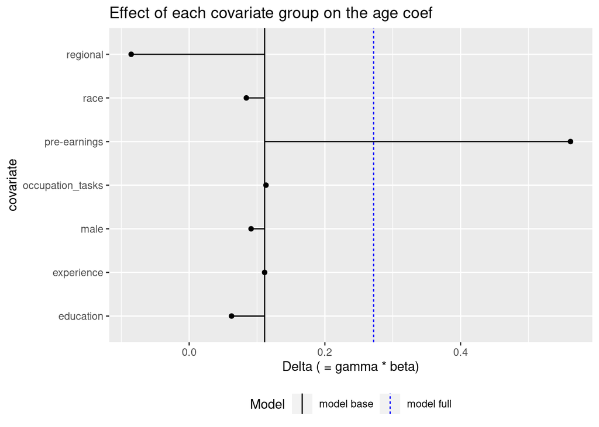

```r
dec_long_2 <- dec_covar(object = model5, var_main = c("age"), format = "long", add_coefs = TRUE, conf.int = TRUE)

# add occupation group
 dec_long_2a<-dec_long_2 %>%
   mutate(group= if_else(covariate %in% c("male"), "male",
                         if_else(covariate %in% c("black","race_white","race_asian"), "race",
                                if_else(covariate %in% c("experience", "experience2"), "experience",
                                        if_else(covariate %in% c("log_real_yearly_earnings_1"), "pre-earnings",
   if_else(covariate %in% occupation, "occupation_group",
           if_else(covariate %in% tasks, "occupation_tasks",
           if_else(covariate %in% region, "regional",
                         "education"))))))))
#
#
sumthose<-  c("beta_K", "beta_K_low", "beta_K_high",
              "gamma","gamma_low", "gamma_high", "delta")

keepthose<- c("beta_var_base", "beta_var_full")

dec_long_2b <- dec_long_2a %>%
  group_by(group)%>%
  summarise_at(vars(all_of(sumthose)), funs(sum), na.rm=TRUE)%>%
  rename(covariate=group)

dec_long_2c <- dec_long_2a %>%
  group_by(group)%>%
  summarise_at(vars(all_of(keepthose)), funs(max), na.rm=TRUE)%>%
  rename(covariate=group)

dec_long_2d <-left_join(dec_long_2b,dec_long_2c,by="covariate")

dec_long_2d$variable<-c(rep("age", times=(dim(dec_long_2d)[1])))

plot_dec(dec_long_2d) +
   ggtitle("Effect of each covariate group on the age coef")
```

### Age - Counterfactual Predictions

The tutorial took us through the steps of decomposing the change in actual wages. This was accomplished by selecting the subset “treatment=1” in the “yu_treatment_control” dataframe. To do the same analysis for the counterfactual, we select the subset “treatment=0”.

```r
outcome<- "log_d_earn"
lm1<- as.formula(
  paste(outcome,
        paste(c(age), collapse = " + "),
        sep = " ~ "))
model1<-lm(lm1, data = yu_df_counter)

lm2<- as.formula(
  paste(outcome,
        paste(c(age,background1), collapse = " + "),
        sep = " ~ "))
model2<-lm(lm2, data = yu_df_counter)

lm3<- as.formula(
  paste(outcome,
        paste(c(age,background1,occexp), collapse = " + "),
        sep = " ~ "))
model3<-lm(lm3, data = yu_df_counter)

lm4<- as.formula(
  paste(outcome,
        paste(c(age,background1,occexp,region), collapse = " + "),
       sep = " ~ "))
model4<-lm(lm4,  data = yu_df_counter)

lm5<- as.formula(
  paste(outcome,
        paste(c(age,background1,occexp,region, "log_real_yearly_earnings_1"), collapse = " + "),
       sep = " ~ "))
model5<-lm(lm5,  data = yu_df_counter)
```

```r
stargazer(model1, model2,model3, model4,model5,
          title="OLS regression of counterfactual difference in log earnings between t and t+1 for program particpants, consecutively adding more covariates",
          type = 'html',
          omit=c(background1,occexp,region,"log_real_yearly_earnings_1"),
          df = FALSE,
          add.lines = list(c("Demographics", "No", "Yes", "Yes", "Yes","Yes"),c("Occupation+Experience", "No", "No","Yes","Yes", "Yes"),  c("Local labor market characteristics", "No", "No", "No", "Yes","Yes" ), c("Earnings at t", "No", "No", "No", "No","Yes")),
          notes.append = FALSE,
          notes = c("Dependent variable: predicted change in log earnings.","Significance level: * p$<$0.10, ** p$<$0.05, *** p$<$0.01. For further notes, see text." )
)
```

**OLS regression of counterfactual difference in log earnings between t and t+1 for program particpants, consecutively adding more covariates**

|  | *Dependent variable:* |  |  |  |  |
| --- | --- | --- | --- | --- | --- |
|  | log_d_earn |  |  |  |  |
|  | (1) | (2) | (3) | (4) | (5) |
| age | 0.466*** | 0.200*** | 0.147*** | 0.128*** | 0.343*** |
|  | (0.039) | (0.032) | (0.028) | (0.027) | (0.007) |
| Constant | 0.805*** | 0.355*** | 0.277*** | 0.746*** | 0.707*** |
|  | (0.064) | (0.053) | (0.046) | (0.287) | (0.067) |
| Demographics | No | Yes | Yes | Yes | Yes |
| Occupation+Experience | No | No | Yes | Yes | Yes |
| Local labor market characteristics | No | No | No | Yes | Yes |
| Earnings at t | No | No | No | No | Yes |
| Observations | 1,132 | 1,132 | 1,132 | 1,132 | 1,132 |
| R<sup>2</sup> | 0.111 | 0.472 | 0.622 | 0.669 | 0.982 |
| Adjusted R<sup>2</sup> | 0.110 | 0.469 | 0.619 | 0.663 | 0.981 |
| Residual Std. Error | 0.157 | 0.121 | 0.103 | 0.096 | 0.023 |
| F Statistic | 140.777*** | 167.570*** | 204.760*** | 102.075*** | 2,594.034*** |
| *Note:* | Dependent variable: predicted change in log earnings. |  |  |  |  |
|  | Significance level: * p<0.10, ** p<0.05, *** p<0.01. For further notes, see text. |  |  |  |  |

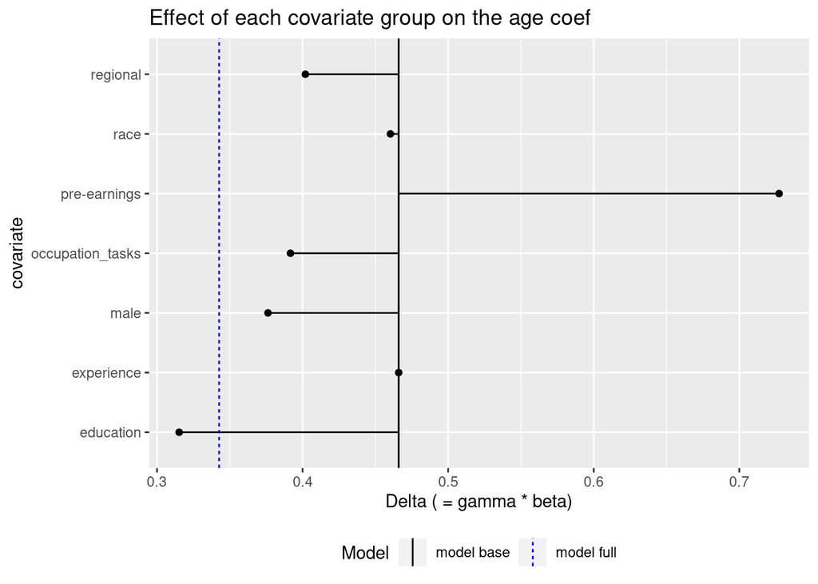

```r
dec_long_2 <- dec_covar(object = model5, var_main = c("age"), format = "long", add_coefs = TRUE, conf.int = TRUE)

# add occupation group
 dec_long_2a<-dec_long_2 %>%
   mutate(group= if_else(covariate %in% c("male"), "male",
                         if_else(covariate %in% c("black","race_white","race_asian"), "race",
                                if_else(covariate %in% c("experience", "experience2"), "experience",
                                        if_else(covariate %in% c("log_real_yearly_earnings_1"), "pre-earnings",
   if_else(covariate %in% occupation, "occupation_group",
           if_else(covariate %in% tasks, "occupation_tasks",
           if_else(covariate %in% region, "regional",
                         "education"))))))))
#
#
sumthose<-  c("beta_K", "beta_K_low", "beta_K_high",
              "gamma","gamma_low", "gamma_high", "delta")

keepthose<- c("beta_var_base", "beta_var_full")

dec_long_2b <- dec_long_2a %>%
  group_by(group)%>%
  summarise_at(vars(all_of(sumthose)), funs(sum), na.rm=TRUE)%>%
  rename(covariate=group)

dec_long_2c <- dec_long_2a %>%
  group_by(group)%>%
  summarise_at(vars(all_of(keepthose)), funs(max), na.rm=TRUE)%>%
  rename(covariate=group)

dec_long_2d <-left_join(dec_long_2b,dec_long_2c,by="covariate")

dec_long_2d$variable<-c(rep("age", times=(dim(dec_long_2d)[1])))

plot_dec(dec_long_2d) +
   ggtitle("Effect of each covariate group on the age coef")
```

### Age - Difference in actual vs counterfactual change in earnings

Finally, to get the difference in actual vs counterfactual earnings, we take a simple difference. This was accomplished in code by reshaping the yu_treatment_control dataframe from long to wide, using the “treatment” variable as the key. Then, the actual column was subtracted by the counterfactual column to produce the change column, which is the outcome variable in the decomposition analysis.

```r
outcome<- "log_d_earn_change"
lm1<- as.formula(
  paste(outcome,
        paste(c(age), collapse = " + "),
        sep = " ~ "))
model1<-lm(lm1, data = yu_df_diff)

lm2<- as.formula(
  paste(outcome,
        paste(c(age,background1), collapse = " + "),
        sep = " ~ "))
model2<-lm(lm2, data = yu_df_diff)

lm3<- as.formula(
  paste(outcome,
        paste(c(age,background1,occexp), collapse = " + "),
        sep = " ~ "))
model3<-lm(lm3, data = yu_df_diff)

lm4<- as.formula(
  paste(outcome,
        paste(c(age,background1,occexp,region), collapse = " + "),
       sep = " ~ "))
model4<-lm(lm4,  data = yu_df_diff)

lm5<- as.formula(
  paste(outcome,
        paste(c(age,background1,occexp,region, "log_real_yearly_earnings_1"), collapse = " + "),
       sep = " ~ "))
model5<-lm(lm5,  data = yu_df_diff)
```

```r
stargazer(model1, model2,model3, model4,model5,
          title="OLS regression of counterfactual difference in log earnings between t and t+1 for program particpants, consecutively adding more covariates",
          type = 'html',
          omit=c(background1,occexp,region,"log_real_yearly_earnings_1"),
          df = FALSE,
          add.lines = list(c("Demographics", "No", "Yes", "Yes", "Yes","Yes"),c("Occupation+Experience", "No", "No","Yes","Yes", "Yes"),  c("Local labor market characteristics", "No", "No", "No", "Yes","Yes" ), c("Earnings at t", "No", "No", "No", "No","Yes")),
          notes.append = FALSE,
          notes = c("Dependent variable: predicted change in log earnings.","Significance level: * p$<$0.10, ** p$<$0.05, *** p$<$0.01. For further notes, see text." )
)
```

**OLS regression of counterfactual difference in log earnings between t and t+1 for program particpants, consecutively adding more covariates**

|  | *Dependent variable:* |  |  |  |  |
| --- | --- | --- | --- | --- | --- |
|  | log_d_earn_change |  |  |  |  |
|  | (1) | (2) | (3) | (4) | (5) |
| age | -0.355*** | -0.211*** | -0.153** | -0.226*** | -0.071 |
|  | (0.075) | (0.077) | (0.077) | (0.078) | (0.077) |
| Constant | -0.104 | 0.162 | 0.253** | 1.050 | 1.022 |
|  | (0.122) | (0.126) | (0.127) | (0.824) | (0.799) |
| Demographics | No | Yes | Yes | Yes | Yes |
| Occupation+Experience | No | No | Yes | Yes | Yes |
| Local labor market characteristics | No | No | No | Yes | Yes |
| Earnings at t | No | No | No | No | Yes |
| Observations | 1,132 | 1,132 | 1,132 | 1,132 | 1,132 |
| R<sup>2</sup> | 0.020 | 0.084 | 0.113 | 0.166 | 0.217 |
| Adjusted R<sup>2</sup> | 0.019 | 0.079 | 0.106 | 0.150 | 0.200 |
| Residual Std. Error | 0.297 | 0.288 | 0.284 | 0.277 | 0.268 |
| F Statistic | 22.640*** | 17.215*** | 15.862*** | 10.062*** | 13.324*** |
| *Note:* | Dependent variable: predicted change in log earnings. |  |  |  |  |
|  | Significance level: * p<0.10, ** p<0.05, *** p<0.01. For further notes, see text. |  |  |  |  |

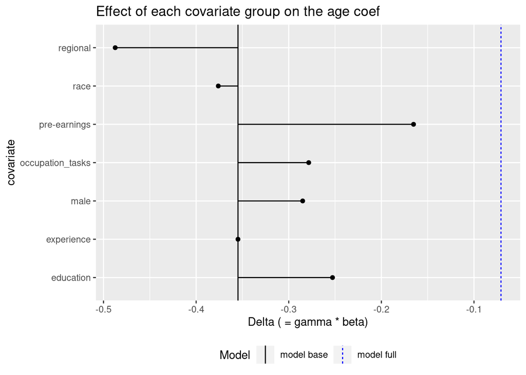

```r
dec_long_2 <- dec_covar(object = model5, var_main = c("age"), format = "long", add_coefs = TRUE, conf.int = TRUE)

# add occupation group
 dec_long_2a<-dec_long_2 %>%
   mutate(group= ifelse(covariate %in% c("male"), "male",
                         if_else(covariate %in% c("black","race_white","race_asian"), "race",
                                if_else(covariate %in% c("experience", "experience2"), "experience",
                                        if_else(covariate %in% c("log_real_yearly_earnings_1"), "pre-earnings",
   if_else(covariate %in% occupation, "occupation_group",
           if_else(covariate %in% tasks, "occupation_tasks",
           if_else(covariate %in% region, "regional",
                         "education"))))))))
#
#
sumthose<-  c("beta_K", "beta_K_low", "beta_K_high",
              "gamma","gamma_low", "gamma_high", "delta")

keepthose<- c("beta_var_base", "beta_var_full")

dec_long_2b <- dec_long_2a %>%
  group_by(group)%>%
  summarise_at(vars(all_of(sumthose)), funs(sum), na.rm=TRUE)%>%
  rename(covariate=group)

dec_long_2c <- dec_long_2a %>%
  group_by(group)%>%
  summarise_at(vars(all_of(keepthose)), funs(max), na.rm=TRUE)%>%
  rename(covariate=group)

dec_long_2d <-left_join(dec_long_2b,dec_long_2c,by="covariate")

dec_long_2d$variable<-c(rep("age", times=(dim(dec_long_2d)[1])))

plot_dec(dec_long_2d) +
   ggtitle("Effect of each covariate group on the age coef")
```

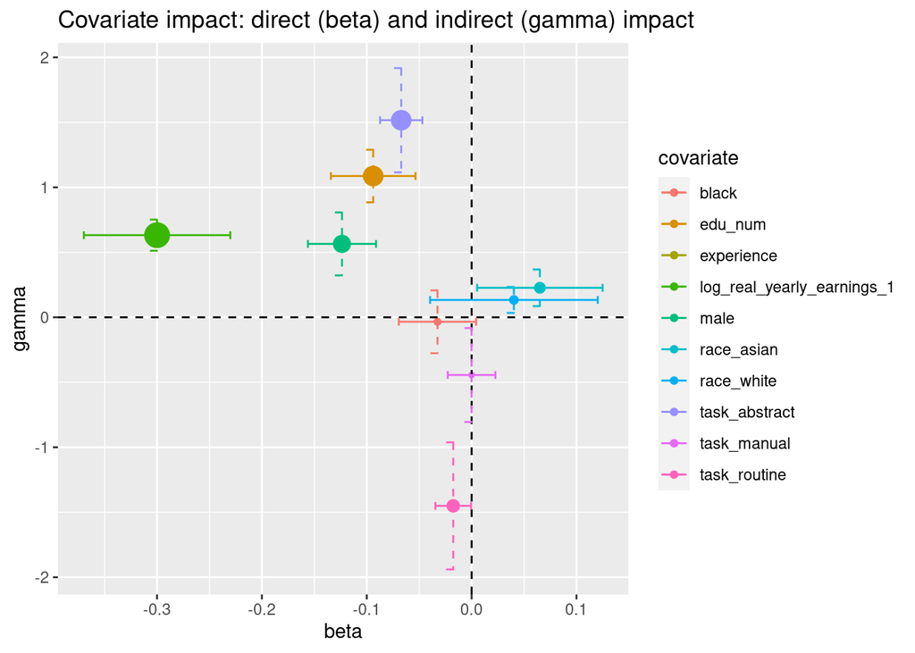

```r
dec_long_2<-dec_long_2 %>%
  filter(!(covariate %in% c(region, colnames(occ_group1))))

plot_gamma_beta(dec_long_2, add_CI = TRUE) +
  ggtitle("Covariate impact: direct (beta) and indirect (gamma) impact")
```

# Additional Analyses

## Heterogeneity by Race and Gender

In this section, we explore the dynamics between race and gender. Since both variables are binary, this amounts to comparing the treatment effects between four groups. Of the 1132 individuals, we have 250 Black men, 209 Black women, 379 non-Black men, and 294 non-Black women.

```r
yu_df <- yu_treatment_control
n_digits <- 4

ate<-lm(log_d_earn~treatment + male*treatment+male, data = subset(yu_df, black==1))
beta1 <- summary(ate)$coefficients[2,1]
beta2 <- summary(ate)$coefficients[3,1]
beta3 <- summary(ate)$coefficients[4,1]

black_female <- exp(beta1)-1
black_male <- exp(beta1+beta3)-1

ate<-lm(log_d_earn~treatment + male*treatment+male, data = subset(yu_df, black==0))
beta1 <- summary(ate)$coefficients[2,1]
beta2 <- summary(ate)$coefficients[3,1]
beta3 <- summary(ate)$coefficients[4,1]

nonblack_female <- exp(beta1)-1
nonblack_male <- exp(beta1+beta3)-1

paste0("YU treatment effect for Black females: ", round(black_female, n_digits)*100, "%")
```

```
## [1] "YU treatment effect for Black females: 61.88%"
```

```r
paste0("YU treatment effect for Black males: ", round(black_male, n_digits)*100, "%")
```

```
## [1] "YU treatment effect for Black males: 50.1%"
```

```r
paste0("YU treatment effect for non-Black females: ", round(nonblack_female, n_digits)*100, "%")
```

```
## [1] "YU treatment effect for non-Black females: 79.96%"
```

```r
paste0("YU treatment effect for non-Black males: ", round(nonblack_male, n_digits)*100, "%")
```

```
## [1] "YU treatment effect for non-Black males: 54.27%"
```

```r
paste0("---------------------------------------")
```

```
## [1] "---------------------------------------"
```

```r
paste0("YU treatment effect on growth rate for Black females is ",
       round(black_female-black_male, n_digits)*100, " percentage points higher than for Black males ")
```

```
## [1] "YU treatment effect on growth rate for Black females is 11.77 percentage points higher than for Black males "
```

```r
paste0("YU treatment effect on growth rate for non-Black females is ",
       round(nonblack_female-nonblack_male, n_digits)*100, " percentage points higher than for non-Black males ")
```

```
## [1] "YU treatment effect on growth rate for non-Black females is 25.69 percentage points higher than for non-Black males "
```

```r
paste0("YU treatment effect on growth rate for non-Black males is ",
       round(nonblack_male-black_male, n_digits)*100, " percentage points higher than for Black males ")
```

```
## [1] "YU treatment effect on growth rate for non-Black males is 4.17 percentage points higher than for Black males "
```

```r
paste0("YU treatment effect on growth rate for non-Black females is ",
       round(nonblack_female-black_female, n_digits)*100, " percentage points higher than for Black females ")
```

```
## [1] "YU treatment effect on growth rate for non-Black females is 18.09 percentage points higher than for Black females "
```

```r
paste0("Full Interactions Model")
```

```
## [1] "Full Interactions Model"
```

```r
ate<-lm(log_d_earn~treatment + male + black + male*black +
          male*treatment + black*treatment + male*black*treatment,
        data = yu_df)
summary(ate)
```

```
##
## Call:
## lm(formula = log_d_earn ~ treatment + male + black + male * black +
##     male * treatment + black * treatment + male * black * treatment,
##     data = yu_df)
##
## Residuals:
##      Min       1Q   Median       3Q      Max
## -1.75090 -0.12777 -0.00607  0.13368  1.17342
##
## Coefficients:
##                       Estimate Std. Error t value             Pr(>|t|)
## (Intercept)          -0.048377   0.014672  -3.297             0.000992 ***
## treatment             0.587578   0.020750  28.317 < 0.0000000000000002 ***
## male                  0.156627   0.019552   8.011  0.00000000000000181 ***
## black                 0.002498   0.022762   0.110             0.912621
## male:black            0.015637   0.030631   0.510             0.609755
## treatment:male       -0.154041   0.027651  -5.571  0.00000002834733997 ***
## treatment:black      -0.105918   0.032190  -3.290             0.001016 **
## treatment:male:black  0.078536   0.043319   1.813             0.069970 .
## ---
## Signif. codes:  0 '***' 0.001 '**' 0.01 '*' 0.05 '.' 0.1 ' ' 1
##
## Residual standard error: 0.2516 on 2256 degrees of freedom
## Multiple R-squared:  0.491,  Adjusted R-squared:  0.4894
## F-statistic: 310.8 on 7 and 2256 DF,  p-value: < 0.00000000000000022
```

```r
beta1 <- summary(ate)$coefficients[2,1]
beta2 <- summary(ate)$coefficients[3,1]
beta3 <- summary(ate)$coefficients[4,1]
beta4 <- summary(ate)$coefficients[5,1]
beta5 <- summary(ate)$coefficients[6,1]
beta6 <- summary(ate)$coefficients[7,1]
beta7 <- summary(ate)$coefficients[8,1]
```

We see that the group with the lowest treatment effect is indeed Black males, consistent with the result that Black people and males see lower treatment effects. However, it is interesting to note that the coefficient of the full interaction term is positive, though only significant at the 10% level. This reflects the fact that the racial gap in treatment effects is much larger for women than for men. The treatment effect gap in real earnings growth between non-Black women and Black women is 18.09 percentage points while the gap between non-Black men and Black men is only 4.17 percentage points. An alternative interpretation is that the gender gap in treatment effects is much larger for non-Black people than for Black people. The treatment effect gap between non-Black women and men is 25.69 percentage points while the gap between Black women and men is 11.77 percentage points.